# Fundraising R Code - FFK221

Austin Thrash - FFK221

2024-03-21

# Fundraising Project

For this project we will be using ‘fundraising.csv’ and ‘future_fundraising.csv’ for our data.

## Background

A national veterans’ organization wishes to develop a predictive model to improve the cost-effectiveness of their direct marketing campaign. The organization, with its in-house database of over 13 million donors, is one of the largest direct-mail fundraisers in the United States. According to their recent mailing records, the overall response rate is 5.1%. Out of those who responded (donated), the average donation is $13.00. Each mailing, which includes a gift of personalized address labels and assortments of cards and envelopes, costs $0.68 to produce and send. Using these facts, we take a sample of this dataset to develop a classification model that can effectively capture donors so that the expected net profit is maximized. Weighted sampling was used, under-representing the non-responders so that the sample has equal numbers of donors and non-donors.

## Data

[output not shown]

## Assignment

### Step 1: Partitioning.

You might think about how to estimate the out of sample error. Either partition the dataset into 80% training and 20% validation or use cross validation (set the seed to 12345).

### Step 2: Model Building.

Follow the following steps to build, evaluate, and choose a model.

#### Exploratory data analysis.

Examine the predictors and evaluate their association with the response variable. Which might be good candidate predictors? Are any collinear with each other?

#### Select classification tool and parameters.

Run at least two classification models of your choosing. Describe the two models that you chose, with sufficient detail (method, parameters, variables, etc.) so that it can be reproduced.

#### Classification under asymmetric response and cost.

Comment on the reasoning behind using weighted sampling to produce a training set with equal numbers of donors and non-donors? Why not use a simple random sample from the original dataset?

#### Evaluate the fit.

Examine the out of sample error for your models. Use tables or graphs to display your results. Is there a model that dominates?

#### Select best model.

From your answer in (4), what do you think is the “best” model?

### Step 3: Testing.

The future fundraising test file contains the attributes for future mailing candidates.

Using your “best” model from Step 2 (number 4), which of these candidates do you predict as donors and non-donors? Use your best model and predict whether the candidate will be a donor or not. Upload your prediction to the leaderboard and comment on the result.

## Write-Up

Document the entire process and findings for audit requirements and future work. Ideally, you should document the following:

- *Business Objectives and Goals.* Successful businesses are based on both goals and objectives, as they clarify the purpose of the business and help identify necessary actions. Goals are general statements of desired achievement, while objectives are the specific steps or actions you take to reach your goal.
- *Data Sources and Data used.* Readers need to know how the data was obtained because the method you choose affects the results and, by extension, how you likely interpreted those  
  results. Here's where you include your discussion on the reasoning behind using weighted sampling to produce a training set with equal numbers of donors and non-donors? Why not use a simple random sample from the original dataset?
- *Type of Analysis performed:* what, why, findings. Methodology is crucial for any branch of scholarship because an unreliable method produces unreliable results and it misappropriates  
  interpretations of findings. In most cases, there are a variety of different methods you can choose to investigate a research problem. This section should make clear the reasons why you  
  chose a particular method or procedure.
- *Exclusions.*Excluding a class from prediction or an observation is done if its precision or coverage statistics don’t meet your threshold of usefulness. For example, exclude it if you don’t  
  want the model to predict a particular output field value. Train the solution definition whose output field values you want to exclude.
- *Variable transformations.* Variable transformation is a way to make the data work better in your model. Data variables can have two types of form: numeric variable and categorical variable, and their transformation should have different approaches. If you made a transformation, talk about it. If you created a new variable, talk about it.
- *Business inputs.* Resources such as people, raw materials, energy, information, or finance that are put into a system (such as an economy, manufacturing plant, computer system) to obtain a desired output.
- *Methodology used, background, benefits.* Research methodology is the specific procedures or techniques used to identify, select, process, and analyze information about a topic. In a research paper, the methodology section allows the reader to critically evaluate a study’s overall validity and reliability. Discuss any alternative methodologies you tried.
- *Model performance and Validation Results.* Evaluating a model is a core part of building an effective machine learning model. There are several evaluation metrics, like confusion matrix,  
  cross-validation, AUC-ROC curve, etc. Evaluation metrics explain the performance of a model. An important aspect of evaluation metrics is their capability to discriminate among model results.
- *Cut-Off Analysis.* While the ROC curve and corresponding AUC give an overall picture of the behavior of a diagnostic test across all cutoff values, there remains a practical need to  
  determine the specific cutoff value that should be used for individuals requiring labeling. The optimal cutoff value is the one that minimizes cost.
- *Recommendations.* Example of recommendations can be defined as a critical suggestion regarding the best course of action in a certain situation. The whole idea of a recommendation  
  is to provide a beneficial guide that will not only resolve certain issues, but result in a beneficial outcome. What percentage of your data would you recommend for a mailing campaign?
- *Pseudo codes for implementation.* Give me your R code. Add it as an appendix to your .pdf document.

# Code

## Reading in the data

```r
# Load the necessary library
library(readr)

# Read the data from the CSV file
data <- read_csv("fundraising.csv")
# Display the first few rows of the dataset
print(head(data))
```

```
## # A tibble: 6 × 21
##   zipconvert2 zipconvert3 zipconvert4 zipconvert5 homeowner num_child income
##   <chr>       <chr>       <chr>       <chr>       <chr>         <dbl>  <dbl>
## 1 Yes         No          No          No          Yes               1      1
## 2 No          No          No          Yes         No                2      5
## 3 No          No          No          Yes         Yes               1      3
## 4 No          Yes         No          No          Yes               1      4
## 5 No          Yes         No          No          Yes               1      4
## 6 No          No          No          Yes         Yes               1      4
## # ℹ 14 more variables: female <chr>, wealth <dbl>, home_value <dbl>,
## #   med_fam_inc <dbl>, avg_fam_inc <dbl>, pct_lt15k <dbl>, num_prom <dbl>,
## #   lifetime_gifts <dbl>, largest_gift <dbl>, last_gift <dbl>,
## #   months_since_donate <dbl>, time_lag <dbl>, avg_gift <dbl>, target <chr>
```

```r
str(data)
```

```
## spc_tbl_ [3,000 × 21] (S3: spec_tbl_df/tbl_df/tbl/data.frame)
##  $ zipconvert2        : chr [1:3000] "Yes" "No" "No" "No" ...
##  $ zipconvert3        : chr [1:3000] "No" "No" "No" "Yes" ...
##  $ zipconvert4        : chr [1:3000] "No" "No" "No" "No" ...
##  $ zipconvert5        : chr [1:3000] "No" "Yes" "Yes" "No" ...
##  $ homeowner          : chr [1:3000] "Yes" "No" "Yes" "Yes" ...
##  $ num_child          : num [1:3000] 1 2 1 1 1 1 1 1 1 1 ...
##  $ income             : num [1:3000] 1 5 3 4 4 4 4 4 4 1 ...
##  $ female             : chr [1:3000] "No" "Yes" "No" "No" ...
##  $ wealth             : num [1:3000] 7 8 4 8 8 8 5 8 8 5 ...
##  $ home_value         : num [1:3000] 698 828 1471 547 482 ...
##  $ med_fam_inc        : num [1:3000] 422 358 484 386 242 450 333 458 541 203 ...
##  $ avg_fam_inc        : num [1:3000] 463 376 546 432 275 498 388 533 575 271 ...
##  $ pct_lt15k          : num [1:3000] 4 13 4 7 28 5 16 8 11 39 ...
##  $ num_prom           : num [1:3000] 46 32 94 20 38 47 51 21 66 73 ...
##  $ lifetime_gifts     : num [1:3000] 94 30 177 23 73 139 63 26 108 161 ...
##  $ largest_gift       : num [1:3000] 12 10 10 11 10 20 15 16 12 6 ...
##  $ last_gift          : num [1:3000] 12 5 8 11 10 20 10 16 7 3 ...
##  $ months_since_donate: num [1:3000] 34 29 30 30 31 37 37 30 31 32 ...
##  $ time_lag           : num [1:3000] 6 7 3 6 3 3 8 6 1 7 ...
##  $ avg_gift           : num [1:3000] 9.4 4.29 7.08 7.67 7.3 ...
##  $ target             : chr [1:3000] "Donor" "Donor" "No Donor" "No Donor" ...
##  - attr(*, "spec")=
##   .. cols(
##   ..   zipconvert2 = col_character(),
##   ..   zipconvert3 = col_character(),
##   ..   zipconvert4 = col_character(),
##   ..   zipconvert5 = col_character(),
##   ..   homeowner = col_character(),
##   ..   num_child = col_double(),
##   ..   income = col_double(),
##   ..   female = col_character(),
##   ..   wealth = col_double(),
##   ..   home_value = col_double(),
##   ..   med_fam_inc = col_double(),
##   ..   avg_fam_inc = col_double(),
##   ..   pct_lt15k = col_double(),
##   ..   num_prom = col_double(),
##   ..   lifetime_gifts = col_double(),
##   ..   largest_gift = col_double(),
##   ..   last_gift = col_double(),
##   ..   months_since_donate = col_double(),
##   ..   time_lag = col_double(),
##   ..   avg_gift = col_double(),
##   ..   target = col_character()
##   .. )
##  - attr(*, "problems")=<externalptr>
```

```r
# Load necessary libraries
library(ggplot2)

# Summary of the numerical attributes
print(summary(data[, sapply(data, is.numeric)]))
```

```
##    num_child         income          wealth        home_value
##  Min.   :1.000   Min.   :1.000   Min.   :0.000   Min.   :   0.0
##  1st Qu.:1.000   1st Qu.:3.000   1st Qu.:5.000   1st Qu.: 554.8
##  Median :1.000   Median :4.000   Median :8.000   Median : 816.5
##  Mean   :1.069   Mean   :3.899   Mean   :6.396   Mean   :1143.3
##  3rd Qu.:1.000   3rd Qu.:5.000   3rd Qu.:8.000   3rd Qu.:1341.2
##  Max.   :5.000   Max.   :7.000   Max.   :9.000   Max.   :5945.0
##   med_fam_inc      avg_fam_inc       pct_lt15k        num_prom
##  Min.   :   0.0   Min.   :   0.0   Min.   : 0.00   Min.   : 11.00
##  1st Qu.: 278.0   1st Qu.: 318.0   1st Qu.: 5.00   1st Qu.: 29.00
##  Median : 355.0   Median : 396.0   Median :12.00   Median : 48.00
##  Mean   : 388.4   Mean   : 432.3   Mean   :14.71   Mean   : 49.14
##  3rd Qu.: 465.0   3rd Qu.: 516.0   3rd Qu.:21.00   3rd Qu.: 65.00
##  Max.   :1500.0   Max.   :1331.0   Max.   :90.00   Max.   :157.00
##  lifetime_gifts    largest_gift       last_gift      months_since_donate
##  Min.   :  15.0   Min.   :   5.00   Min.   :  0.00   Min.   :17.00
##  1st Qu.:  45.0   1st Qu.:  10.00   1st Qu.:  7.00   1st Qu.:29.00
##  Median :  81.0   Median :  15.00   Median : 10.00   Median :31.00
##  Mean   : 110.7   Mean   :  16.65   Mean   : 13.48   Mean   :31.13
##  3rd Qu.: 135.0   3rd Qu.:  20.00   3rd Qu.: 16.00   3rd Qu.:34.00
##  Max.   :5674.9   Max.   :1000.00   Max.   :219.00   Max.   :37.00
##     time_lag         avg_gift
##  Min.   : 0.000   Min.   :  2.139
##  1st Qu.: 3.000   1st Qu.:  6.333
##  Median : 5.000   Median :  9.000
##  Mean   : 6.876   Mean   : 10.669
##  3rd Qu.: 9.000   3rd Qu.: 12.800
##  Max.   :77.000   Max.   :122.167
```

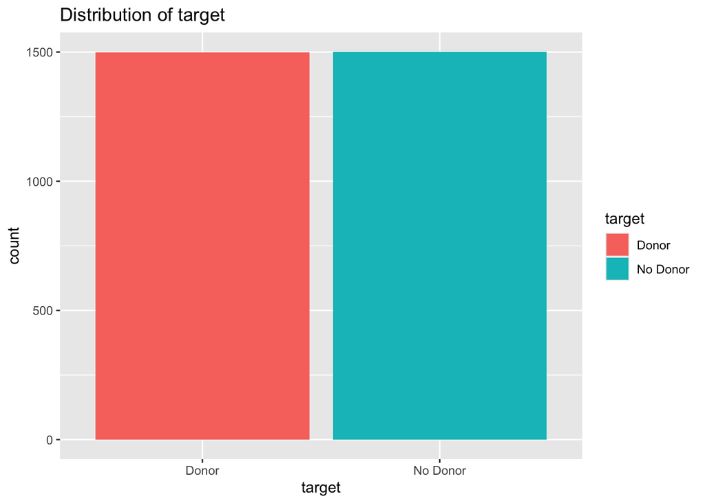

```r
# Plotting distribution of a few numerical attributes
ggplot(data, aes(x = target, fill = target)) + geom_bar() + ggtitle("Distribution of target")
```

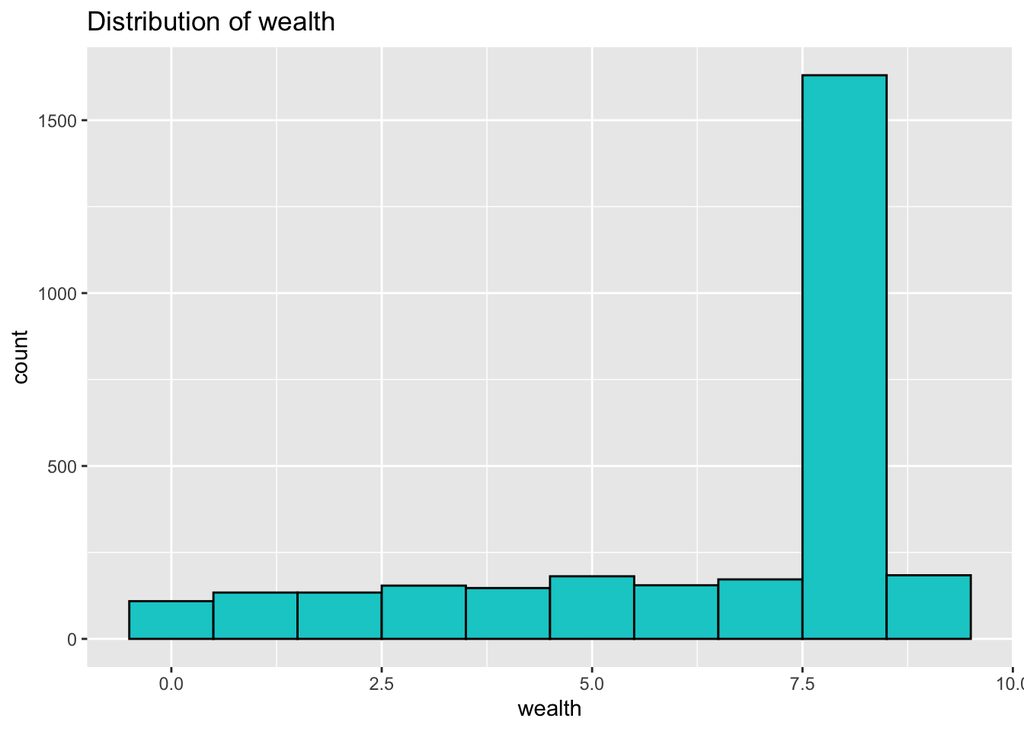

```r
ggplot(data, aes(x = wealth)) + geom_histogram(bins = 10, fill = "cyan3", color = "black") + ggtitle("Distribution of wealth")
```

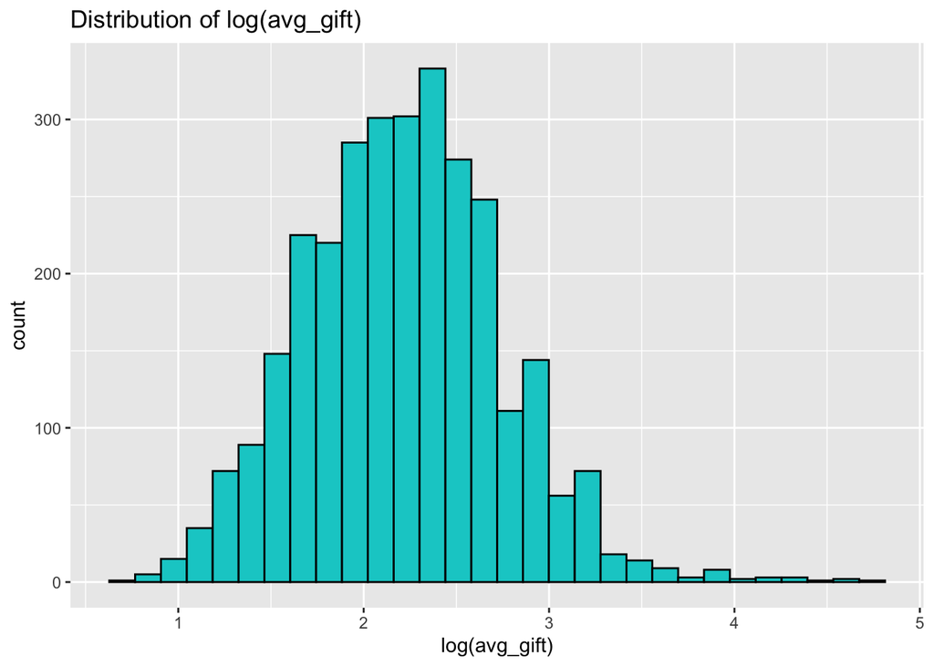

```r
ggplot(data, aes(x = log(avg_gift))) + geom_histogram(bins = 30, fill = "cyan3", color = "black") + ggtitle("Distribution of log(avg_gift)")
```

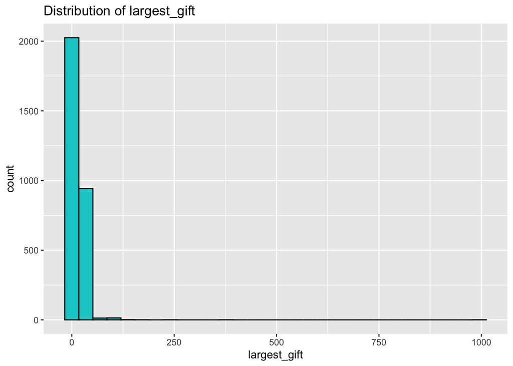

```r
ggplot(data, aes(x = largest_gift)) + geom_histogram(bins = 30, fill = "cyan3", color = "black") + ggtitle("Distribution of largest_gift")
```

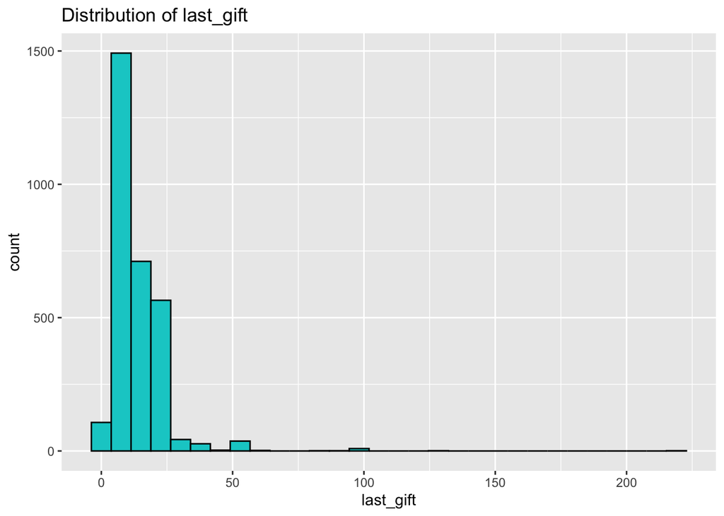

```r
ggplot(data, aes(x = last_gift)) + geom_histogram(bins = 30, fill = "cyan3", color = "black") + ggtitle("Distribution of last_gift")
```

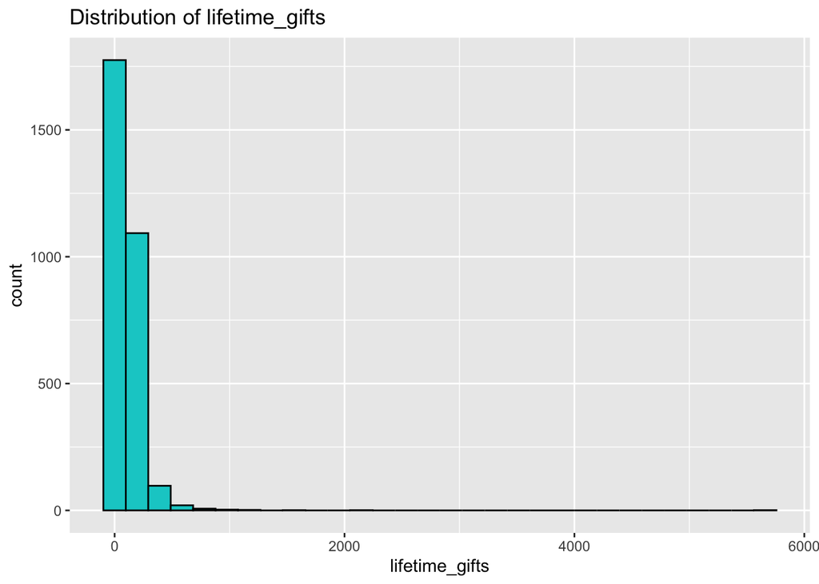

```r
ggplot(data, aes(x = lifetime_gifts)) + geom_histogram(bins = 30, fill = "cyan3", color = "black") + ggtitle("Distribution of lifetime_gifts")
```

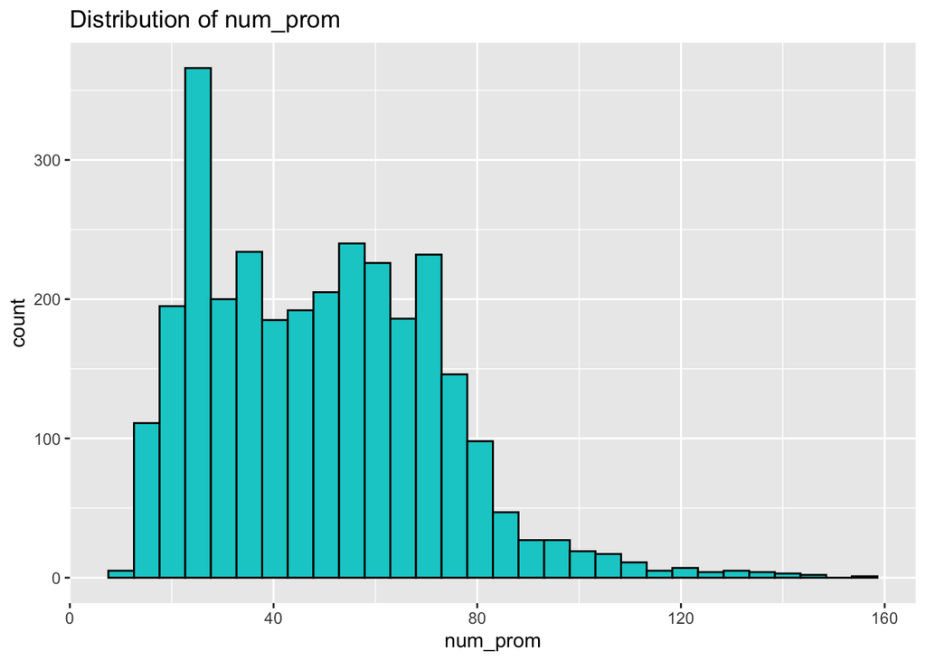

```r
ggplot(data, aes(x = num_prom)) + geom_histogram(bins = 30, fill = "cyan3", color = "black") + ggtitle("Distribution of num_prom")
```

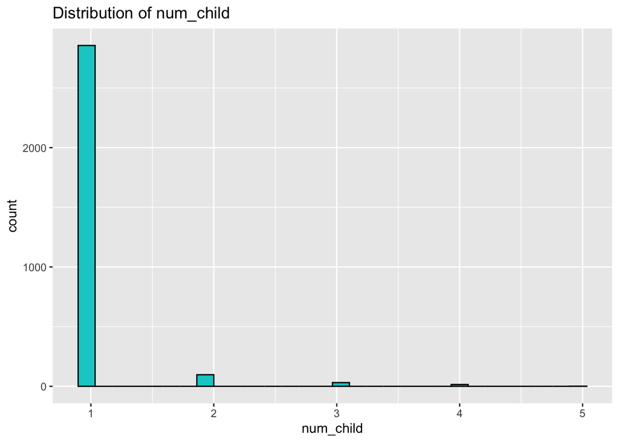

```r
ggplot(data, aes(x = num_child)) + geom_histogram(bins = 30, fill = "cyan3", color = "black") + ggtitle("Distribution of num_child")
```

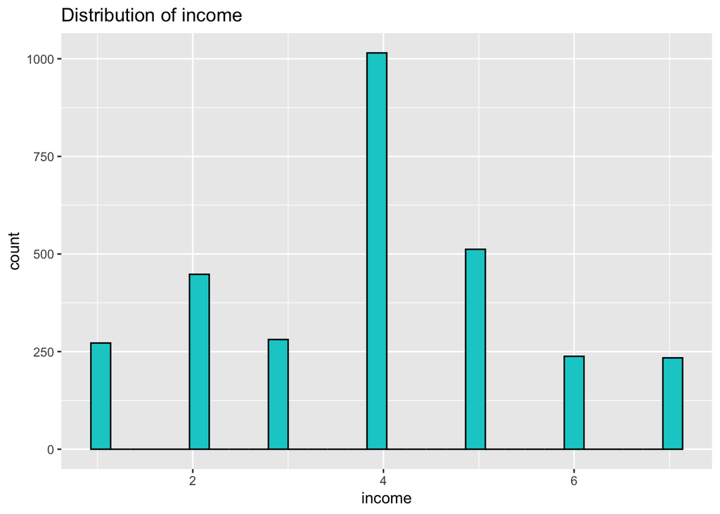

```r
ggplot(data, aes(x = income)) + geom_histogram(bins = 30, fill = "cyan3", color = "black") + ggtitle("Distribution of income")
```

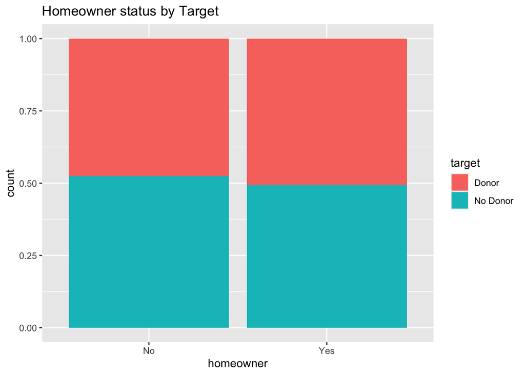

```r
# Association with target variable example
ggplot(data, aes(x = homeowner, fill = target)) + geom_bar(position = "fill") + ggtitle("Homeowner status by Target")
```

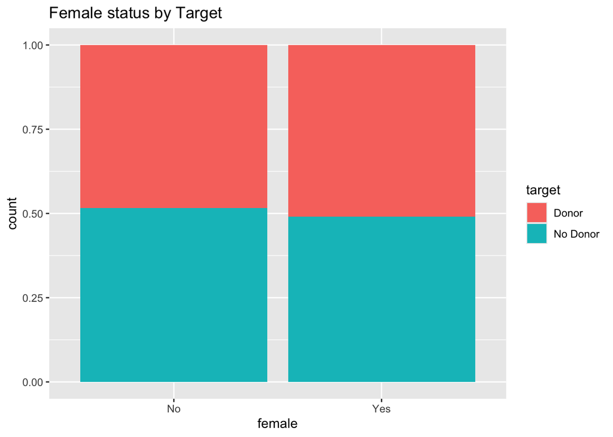

```r
# Association with target variable example
ggplot(data, aes(x = female, fill = target)) + geom_bar(position = "fill") + ggtitle("Female status by Target")
```

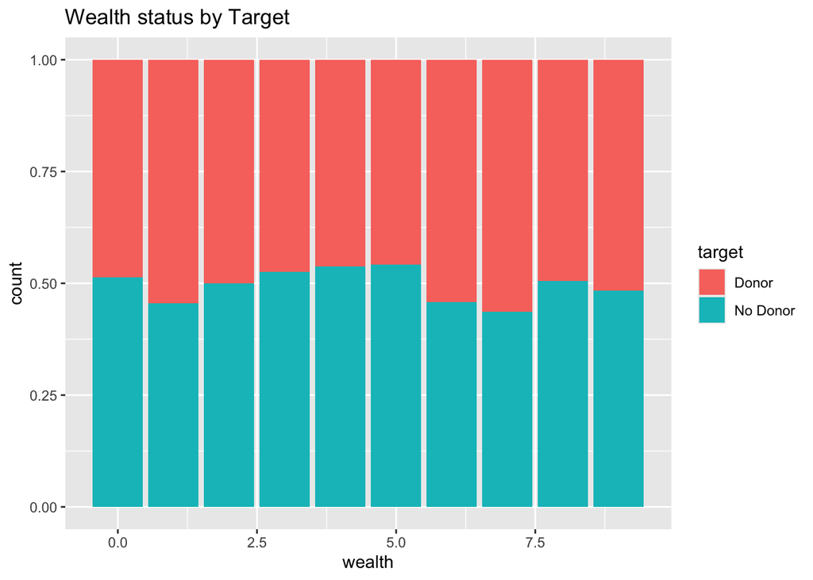

```r
# Association with target variable example
ggplot(data, aes(x = wealth, fill = target)) + geom_bar(position = "fill") + ggtitle("Wealth status by Target")
```

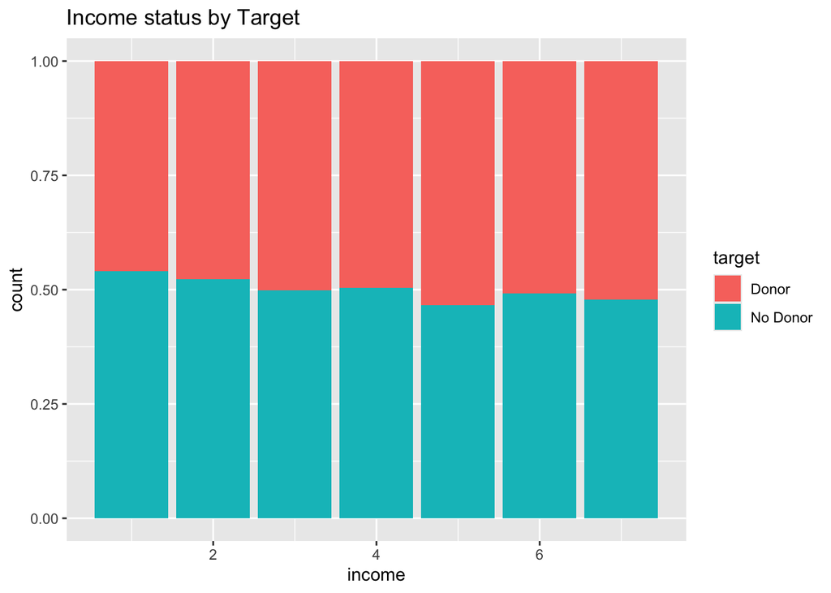

```r
# Association with target variable example
ggplot(data, aes(x = income, fill = target)) + geom_bar(position = "fill") + ggtitle("Income status by Target")
```

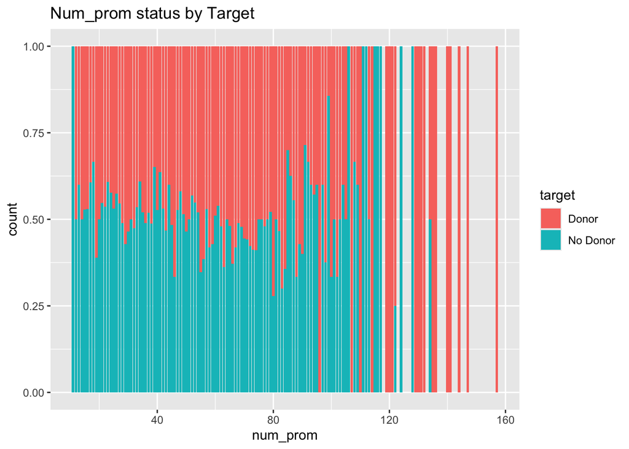

```r
# Association with target variable example
ggplot(data, aes(x = num_prom, fill = target)) + geom_bar(position = "fill") + ggtitle("Num_prom status by Target")
```

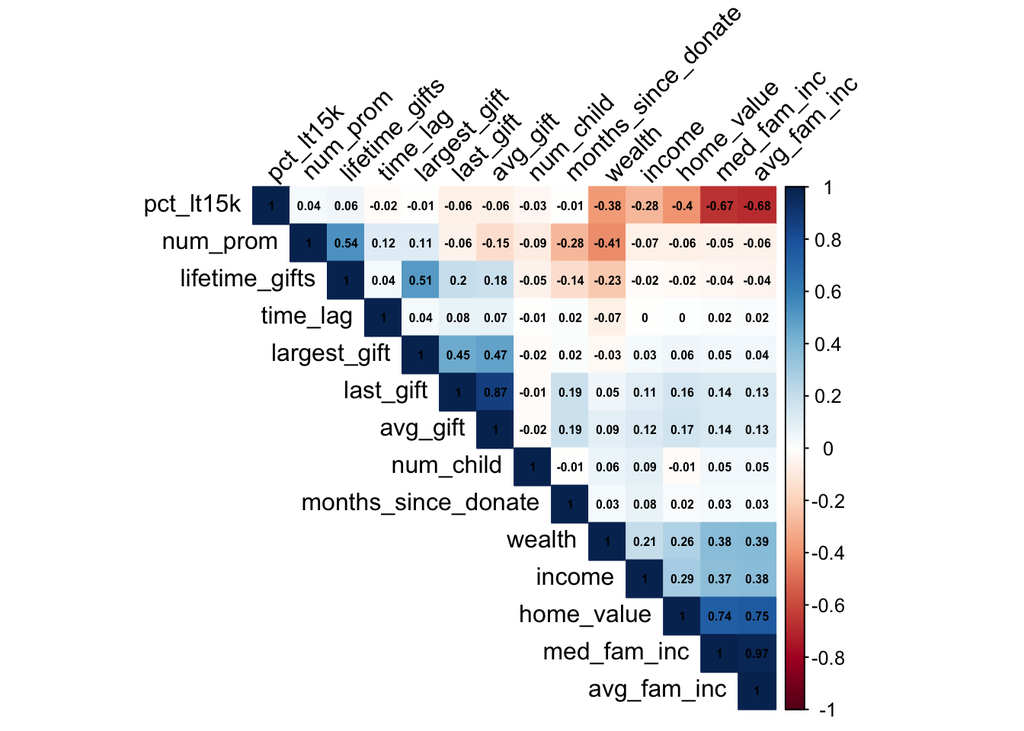

```r
# Load necessary library for correlation matrix
library(corrplot)

# Compute the correlation matrix for numerical attributes
numerical_data <- data[, sapply(data, is.numeric)]
cor_matrix <- cor(numerical_data, use = "complete.obs")  # Handles missing values by excluding them

# Plot the correlation matrix
corrplot(cor_matrix, method = "color", type = "upper", order = "hclust",
         tl.col = "black", tl.srt = 45, addCoef.col = "black", number.cex = 0.5)
```

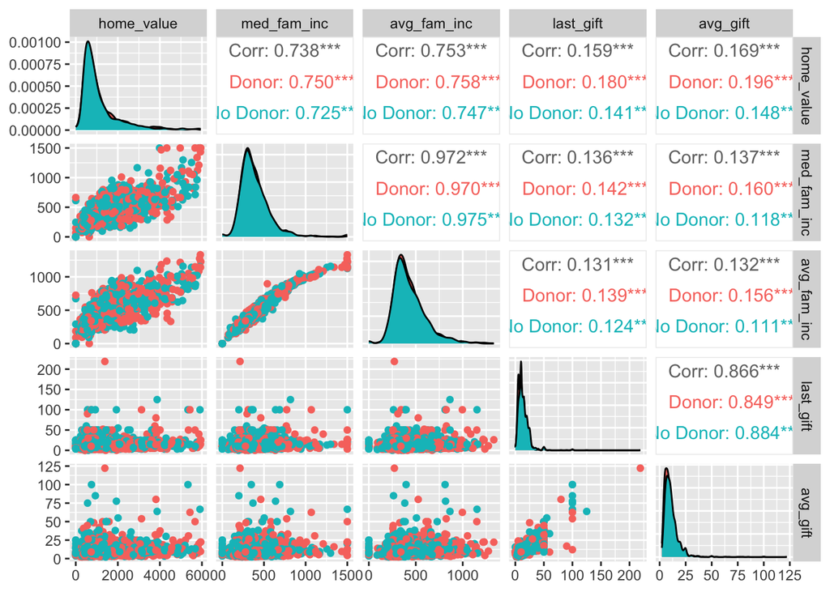

```r
ggpairs(data[, c(10, 11, 12, 17, 20)], ggplot2::aes(colour = data$target))
```

## Preparing Cross Validation

```r
set.seed(12345)
# Initialize zipconvert1 with 0
data$zipconvert1 <- "No"

# Set zipconvert1 to 1 where all other zipconverts are 0
data$zipconvert1[with(data, zipconvert2 == "No" & zipconvert3 == "No" & zipconvert4 == "No" & zipconvert5 == "No")] <- "Yes"

data$zip_group[data$zipconvert1 == "Yes"] <- '1'
data$zip_group[data$zipconvert2 == "Yes"] <- '2'
data$zip_group[data$zipconvert3 == "Yes"] <- '3'
data$zip_group[data$zipconvert4 == "Yes"] <- '4'
data$zip_group[data$zipconvert5 == "Yes"] <- '5'

# Ensure it's a factor
data$zip_group <- as.factor(data$zip_group)

# Optionally remove the old zipconvert columns
data$zipconvert1 <- NULL
data$zipconvert2 <- NULL
data$zipconvert3 <- NULL
data$zipconvert4 <- NULL
data$zipconvert5 <- NULL
# Assuming 'target' is your factor column in the dataset 'data'
data$target <- as.factor(data$target)
levels(data$target) <- c("Donor", "No.Donor")  # Adjust as necessary to match exact output requirements
data$homeowner <-as.factor(data$homeowner)
data$income <- as.factor(data$income)
data$female <- as.factor(data$female)
data$wealth <- as.factor(data$wealth)
```

```r
glm.full = glm(target ~ . - avg_fam_inc - last_gift -home_value, data = data, family = binomial)

glm.vif = vif(glm.full)

glm.vif
```

```
##                         GVIF Df GVIF^(1/(2*Df))
## homeowner           1.225298  1        1.106932
## num_child           1.029501  1        1.014643
## income              1.514065  6        1.035171
## female              1.022612  1        1.011243
## wealth              2.466719  9        1.051440
## med_fam_inc         2.280058  1        1.509986
## pct_lt15k           2.050342  1        1.431901
## num_prom            2.286675  1        1.512176
## lifetime_gifts      2.057550  1        1.434416
## largest_gift        1.842542  1        1.357403
## months_since_donate 1.136586  1        1.066108
## time_lag            1.047255  1        1.023355
## avg_gift            1.536831  1        1.239690
## zip_group           1.101284  4        1.012133
```

```r
set.seed(12345)
import_features = train(target ~ . - zip_group - avg_fam_inc,
               data = data,
               method = "rf",
               importance = TRUE,
               trControl = trainControl(method = "cv", number = 10, verbose = TRUE))
import_features
```

```
## Random Forest
##
## 3000 samples
##   17 predictor
##    2 classes: 'Donor', 'No.Donor'
##
## No pre-processing
## Resampling: Cross-Validated (10 fold)
## Summary of sample sizes: 2700, 2700, 2700, 2701, 2700, 2700, ...
## Resampling results across tuning parameters:
##
##   mtry  Accuracy   Kappa
##    2    0.5499945  0.09999411
##   15    0.5220012  0.04404265
##   28    0.5323245  0.06466842
##
## Accuracy was used to select the optimal model using the largest value.
## The final value used for the model was mtry = 2.
```

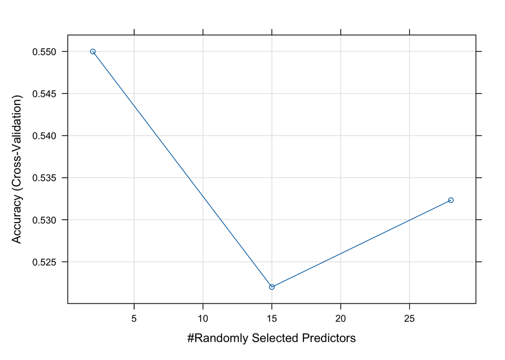

```r
plot(import_features, m.target = "NULL",
  plots.one.page = TRUE, sorted = TRUE, verbose = F)
```

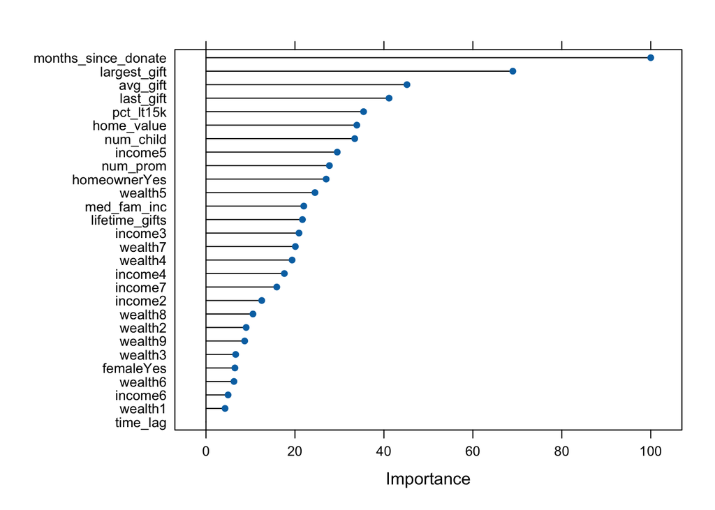

```r
plot(varImp(import_features))
```

```r
# Load the necessary library
library(caret)

customSummary <- function(data, lev = NULL, model = NULL) {
  # Calculate confusion matrix
  conf <- confusionMatrix(data$pred, data$obs, positive = lev[2])

  # Extract metrics
  out <- c(accuracy = conf$overall['Accuracy'],
           precision = conf$byClass['Precision'],
           recall = conf$byClass['Recall'],
           F1 = conf$byClass['F1'])
  names(out) <- c("Accuracy", "Precision", "Recall", "F1")
  out
}

# Set up cross-validation
set.seed(12345)  # for reproducibility
train_control <- trainControl(
  method = "repeatedcv",    # Repeated cross-validation
  number = 10,              # Number of folds in the k-fold process
  repeats = 3,              # Number of repeats
  savePredictions = "final",
  classProbs = TRUE,        # If classification, save class probabilities
  summaryFunction = customSummary  # Custom summary function for binary classification
)
```

## Logistic Regression - All Features

### Training

```r
set.seed(12345)
logistic_model <- train(target ~ .,
                        data = data,
                        method = "glm",
                        family = "binomial",
                        trControl = train_control,
                        preProcess = c("center", "scale"),
                        metric = "ROC")  # Optimization metric is ROC AUC
```

### Results Overall

```r
results <- logistic_model$results
print(results[, c("Accuracy", "Precision", "Recall", "F1")])
```

```
##    Accuracy Precision    Recall        F1
## 1 0.5494464 0.5510418 0.5427653 0.5464273
```

### Confusion Matrix

```r
# Confusion Matrix and classification summary
confusionMatrix(predict(logistic_model, data), data$target)
```

```
## Confusion Matrix and Statistics
##
##           Reference
## Prediction Donor No.Donor
##   Donor      877      647
##   No.Donor   622      854
##
##                Accuracy : 0.577
##                  95% CI : (0.5591, 0.5948)
##     No Information Rate : 0.5003
##     P-Value [Acc > NIR] : <2e-16
##
##                   Kappa : 0.154
##
##  Mcnemar's Test P-Value : 0.5005
##
##             Sensitivity : 0.5851
##             Specificity : 0.5690
##          Pos Pred Value : 0.5755
##          Neg Pred Value : 0.5786
##              Prevalence : 0.4997
##          Detection Rate : 0.2923
##    Detection Prevalence : 0.5080
##       Balanced Accuracy : 0.5770
##
##        'Positive' Class : Donor
##
```

### ROC and AUC

```r
library(pROC)
```

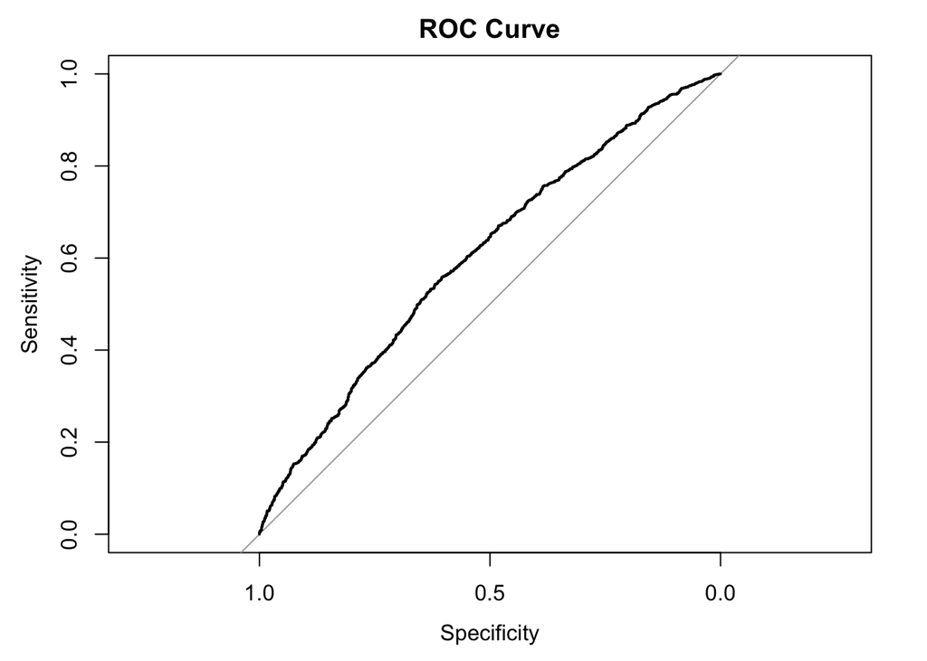

```r
# Predict probabilities
probabilities <- predict(logistic_model, data, type = "prob")

# Calculate ROC curve
roc_curve <- roc(response = data$target, predictor = probabilities[, "Donor"])
# Plot ROC curve
plot(roc_curve, main = "ROC Curve")
```

```r
auc(roc_curve)
```

```
## Area under the curve: 0.6036
```

```r
## Scored 0.46
```

```r
# Predict probabilities on the validation set
predictions <- predict(logistic_model, data, type = "prob")

probabilities <- predictions$Donor

# Define cost of sending a mail and average donation amount
cost_per_mail <- 0.68  # Cost of each mailing
average_donation <- 13.00  # Average donation received from a positive response

# Initialize a vector to store net profits for each threshold
thresholds <- seq(0.1, 0.9, by = 0.1)
net_profits <- numeric(length(thresholds))

# Calculate net profit for each threshold
for (i in seq_along(thresholds)) {
  cut_off <- thresholds[i]

  # Predict labels based on cut-off
  predicted_labels <- ifelse(probabilities > cut_off, 1, 0)

  # Calculate True Positives and False Positives
  true_positives <- sum(predicted_labels == 1 & data$target == "Donor")
  false_positives <- sum(predicted_labels == 1 & data$target == "No Donor")

  # Calculate cost and revenue
  cost <- false_positives * cost_per_mail
  revenue <- true_positives * average_donation

  # Calculate net profit
  net_profits[i] <- revenue - cost
}

# Identify the optimal threshold
optimal_index <- which.max(net_profits)
optimal_threshold <- thresholds[optimal_index]
optimal_net_profit <- net_profits[optimal_index]

cat("Optimal Cut-off:", optimal_threshold, "\n",
    "Maximum Net Profit:", optimal_net_profit, "\n")
```

```
## Optimal Cut-off: 0.1
##  Maximum Net Profit: 19487
```

### Hyperparameter and feature selection tuning

```r
glm.empty = glm(target ~ 1, data = data, family = binomial)
glm.full = glm(target ~ . -zip_group, data = data, family = binomial)

step.AIC = step(glm.empty, scope = list(upper=glm.full),
     direction ="both",test ="Chisq", trace = F)

summary(step.AIC)
```

```
##
## Call:
## glm(formula = target ~ months_since_donate + last_gift + num_child +
##     home_value + num_prom + homeowner, family = binomial, data = data)
##
## Coefficients:
##                       Estimate Std. Error z value Pr(>|z|)
## (Intercept)         -1.936e+00  3.697e-01  -5.238 1.63e-07 ***
## months_since_donate  5.846e-02  9.905e-03   5.902 3.58e-09 ***
## last_gift            1.215e-02  3.915e-03   3.103  0.00192 **
## num_child            2.558e-01  1.121e-01   2.281  0.02256 *
## home_value          -6.978e-05  3.992e-05  -1.748  0.08045 .
## num_prom            -2.821e-03  1.711e-03  -1.648  0.09935 .
## homeownerYes        -1.322e-01  8.886e-02  -1.488  0.13685
## ---
## Signif. codes:  0 '***' 0.001 '**' 0.01 '*' 0.05 '.' 0.1 ' ' 1
##
## (Dispersion parameter for binomial family taken to be 1)
##
##     Null deviance: 4158.9  on 2999  degrees of freedom
## Residual deviance: 4081.1  on 2993  degrees of freedom
## AIC: 4095.1
##
## Number of Fisher Scoring iterations: 4
```

```r
library(caret)
set.seed(12345)

# Define a custom summary function for binary classification metrics
customSummary <- function(data, lev = NULL, model = NULL) {
  # Calculate confusion matrix
  conf <- confusionMatrix(data$pred, data$obs, positive = lev[2])

  # Extract metrics
  out <- c(accuracy = conf$overall['Accuracy'],
           precision = conf$byClass['Precision'],
           recall = conf$byClass['Recall'],
           F1 = conf$byClass['F1'])
  names(out) <- c("Accuracy", "Precision", "Recall", "F1")
  out
}

# Define the training control
train_control <- trainControl(
  method = "cv",
  number = 10,
  savePredictions = "final",
  classProbs = TRUE,
  summaryFunction = customSummary
)

# Define the tuning grid
tuning_grid <- expand.grid(
  .alpha = seq(0, 1, by = 0.01),  # Mixing ratio of L1 and L2
  .lambda = 10^seq(-3, -1, by = 0.1)  # Regularization strength
)

# Train the model
logistic_model <- train(
  target ~ months_since_donate + last_gift,
  data = data,
  method = "glmnet",
  tuneGrid = tuning_grid,
  trControl = train_control,
  preProcess = c("center", "scale"),
  metric = "ROC",
  family = "binomial"
)
# Print the overall model summary
print(logistic_model)
```

```
## glmnet
##
## 3000 samples
##    2 predictor
##    2 classes: 'Donor', 'No.Donor'
##
## Pre-processing: centered (2), scaled (2)
## Resampling: Cross-Validated (10 fold)
## Summary of sample sizes: 2700, 2700, 2700, 2701, 2700, 2700, ...
## Resampling results across tuning parameters:
##
##   alpha  lambda       Accuracy   Precision  Recall     F1
##   0.00   0.001000000  0.5570024  0.5665998  0.4956909  0.5281941
##   0.00   0.001258925  0.5570024  0.5665998  0.4956909  0.5281941
##   0.00   0.001584893  0.5570024  0.5665998  0.4956909  0.5281941
##   0.00   0.001995262  0.5570024  0.5665998  0.4956909  0.5281941
##   0.00   0.002511886  0.5570024  0.5665998  0.4956909  0.5281941
##   0.00   0.003162278  0.5570024  0.5665998  0.4956909  0.5281941
##   0.00   0.003981072  0.5570024  0.5665998  0.4956909  0.5281941
##   0.00   0.005011872  0.5570024  0.5665998  0.4956909  0.5281941
##   0.00   0.006309573  0.5570024  0.5665998  0.4956909  0.5281941
##   0.00   0.007943282  0.5570024  0.5665998  0.4956909  0.5281941
##   0.00   0.010000000  0.5570024  0.5665998  0.4956909  0.5281941
##   0.00   0.012589254  0.5570024  0.5665998  0.4956909  0.5281941
##   0.00   0.015848932  0.5570024  0.5665998  0.4956909  0.5281941
##   0.00   0.019952623  0.5570024  0.5665998  0.4956909  0.5281941
##   0.00   0.025118864  0.5563368  0.5654953  0.4950287  0.5272963
##   0.00   0.031622777  0.5566713  0.5658203  0.4956954  0.5278247
##   0.00   0.039810717  0.5563379  0.5653800  0.4956954  0.5276298
##   0.00   0.050118723  0.5560046  0.5649838  0.4956954  0.5274472
##   0.00   0.063095734  0.5560046  0.5649838  0.4956954  0.5274472
##   0.00   0.079432823  0.5560046  0.5649838  0.4956954  0.5274472
##   0.00   0.100000000  0.5563390  0.5651778  0.4970287  0.5283099
##   0.01   0.001000000  0.5570024  0.5666830  0.4950243  0.5278640
##   0.01   0.001258925  0.5570024  0.5666830  0.4950243  0.5278640
##   0.01   0.001584893  0.5570024  0.5666830  0.4950243  0.5278640
##   0.01   0.001995262  0.5570024  0.5666830  0.4950243  0.5278640
##   0.01   0.002511886  0.5570024  0.5666830  0.4950243  0.5278640
##   0.01   0.003162278  0.5570024  0.5666830  0.4950243  0.5278640
##   0.01   0.003981072  0.5570024  0.5666830  0.4950243  0.5278640
```

[output cut: 2081 more lines]

```
##   1.00   0.007943282  0.5583335  0.5673371  0.4996865  0.5307931
##   1.00   0.010000000  0.5583335  0.5673509  0.4996865  0.5308066
##   1.00   0.012589254  0.5600001  0.5688656  0.5036909  0.5335522
##   1.00   0.015848932  0.5596657  0.5679087  0.5063532  0.5346391
##   1.00   0.019952623  0.5566646  0.5646296  0.5016821  0.5308728
##   1.00   0.025118864  0.5566657  0.5657943  0.4930287  0.5261500
##   1.00   0.031622777  0.5549957  0.5684050  0.4670464  0.5117205
##   1.00   0.039810717  0.5526624  0.5675536  0.4510464  0.5020472
##   1.00   0.050118723  0.5529957  0.5685606  0.4457130  0.4992777
##   1.00   0.063095734  0.5403357  0.5352359  0.6596159  0.5860225
##   1.00   0.079432823  0.5003333  0.5003333  1.0000000  0.6669626
##   1.00   0.100000000  0.5003333  0.5003333  1.0000000  0.6669626
##
## Accuracy was used to select the optimal model using the largest value.
## The final values used for the model were alpha = 0.19 and lambda = 0.07943282.
```

```r
# Display the best tuning parameters
best_params <- logistic_model$bestTune
print(paste("Best alpha:", best_params$alpha))
```

```
## [1] "Best alpha: 0.19"
```

```r
print(paste("Best lambda:", best_params$lambda))
```

```
## [1] "Best lambda: 0.0794328234724282"
```

```r
results <- logistic_model$results
print(paste("Accuracy:", mean(results[, "Accuracy"])))
```

```
## [1] "Accuracy: 0.555783355980747"
```

```r
print(paste("Precision:",mean(results[, "Precision"])))
```

```
## [1] "Precision: 0.565063839374358"
```

```r
print(paste("Recall:",mean(results[, "Recall"])))
```

```
## [1] "Recall: 0.508537825778794"
```

```r
print(paste("F1:",mean(results[, "F1"])))
```

```
## [1] "F1: 0.531611541690423"
```

### Hyper Tune Results Overall

```r
# Load necessary libraries
library(caret)
library(pROC)

# Assume logistic_model is already trained and available

# Predict on the training dataset to evaluate performance
predictions <- predict(logistic_model, data, type = "raw")
probabilities <- predict(logistic_model, data, type = "prob")

# Calculate the ROC curve and AUC
roc_result <- roc(data$target, probabilities[, "Donor"])  # Adjust class label if necessary
# Print the AUC
print(paste("AUC of the best model:", auc(roc_result)))
```

```
## [1] "AUC of the best model: 0.57971425765078"
```

```r
# Generate a confusion matrix
confusionMatrix(predictions, data$target)
```

```
## Confusion Matrix and Statistics
##
##           Reference
## Prediction Donor No.Donor
##   Donor      928      754
##   No.Donor   571      747
##
##                Accuracy : 0.5583
##                  95% CI : (0.5403, 0.5762)
##     No Information Rate : 0.5003
##     P-Value [Acc > NIR] : 1.131e-10
##
##                   Kappa : 0.1167
##
##  Mcnemar's Test P-Value : 5.735e-07
##
##             Sensitivity : 0.6191
##             Specificity : 0.4977
##          Pos Pred Value : 0.5517
##          Neg Pred Value : 0.5668
##              Prevalence : 0.4997
##          Detection Rate : 0.3093
##    Detection Prevalence : 0.5607
##       Balanced Accuracy : 0.5584
##
##        'Positive' Class : Donor
##
```

### Hyper Tune ROC and AUC

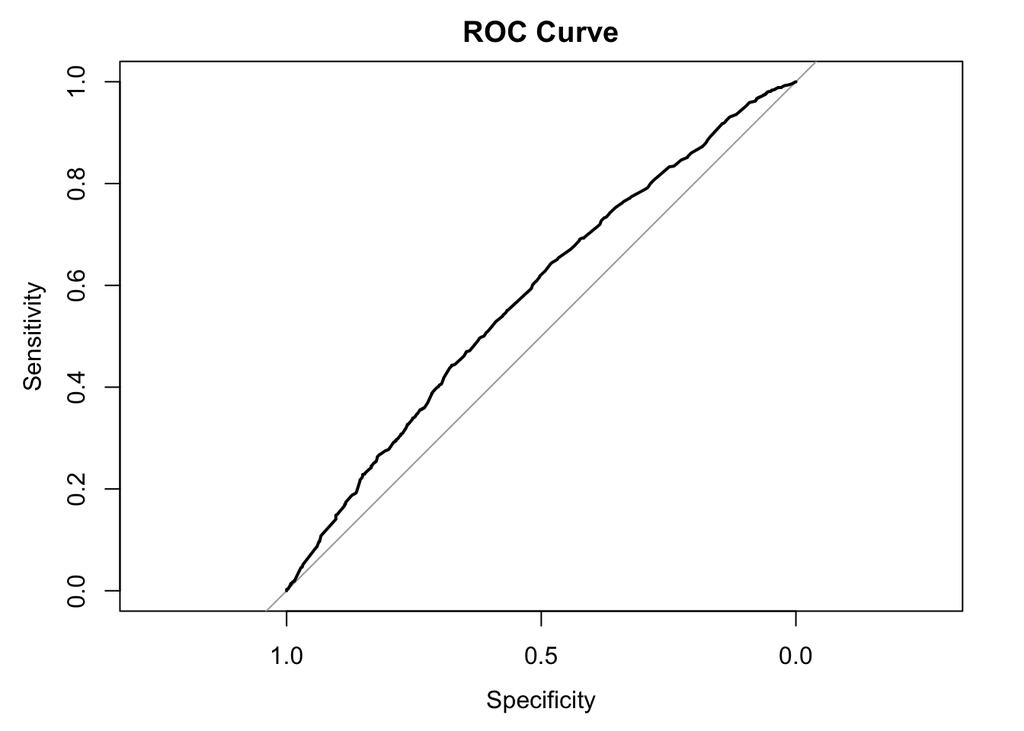

```r
library(pROC)

# Predict probabilities
probabilities <- predict(logistic_model, data, type = "prob")

# Calculate ROC curve
roc_curve <- roc(response = data$target, predictor = probabilities[, "Donor"])
# Plot ROC curve
plot(roc_curve, main = "ROC Curve")
```

```r
auc(roc_curve)
```

```
## Area under the curve: 0.5797
```

## Random Forest

### Training

```r
set.seed(12345)

customSummary <- function(data, lev = NULL, model = NULL) {
  # Calculate confusion matrix
  conf <- confusionMatrix(data$pred, data$obs, positive = lev[2])

  # Extract metrics
  out <- c(accuracy = conf$overall['Accuracy'],
           precision = conf$byClass['Precision'],
           recall = conf$byClass['Recall'],
           F1 = conf$byClass['F1'])
  names(out) <- c("Accuracy", "Precision", "Recall", "F1")
  out
}

train_control = trainControl(method="repeatedcv",
                             number=10,
                             repeats=3,
                             summaryFunction = customSummary)

random.forrest = train(target ~ months_since_donate + last_gift,
                data = data,
                method = 'rf',
                trControl = train_control,
                importance = TRUE)
```

### Results

```r
results <- random.forrest$results
print(paste("Accuracy:", mean(results[, "Accuracy"])))
```

```
## [1] "Accuracy: 0.520104870301028"
```

```r
print(paste("Precision:",mean(results[, "Precision"])))
```

```
## [1] "Precision: 0.522000531177632"
```

```r
print(paste("Recall:",mean(results[, "Recall"])))
```

```
## [1] "Recall: 0.499224429727741"
```

```r
print(paste("F1:",mean(results[, "F1"])))
```

```
## [1] "F1: 0.509398541951713"
```

### Confusion Matrix

```r
# Predict on the training dataset to evaluate performance
predictions <- predict(random.forrest, data, type = "raw")
probabilities <- predict(random.forrest, data, type = "prob")

# Calculate the ROC curve and AUC
roc_result <- roc(data$target, probabilities[, "Donor"])  # Adjust class label if necessary
# Print the AUC
print(paste("AUC of the best model:", auc(roc_result)))
```

```
## [1] "AUC of the best model: 0.671835631926948"
```

```r
# Generate a confusion matrix
confusionMatrix(predictions, data$target)
```

```
## Confusion Matrix and Statistics
##
##           Reference
## Prediction Donor No.Donor
##   Donor      973      608
##   No.Donor   526      893
##
##                Accuracy : 0.622
##                  95% CI : (0.6044, 0.6394)
##     No Information Rate : 0.5003
##     P-Value [Acc > NIR] : < 2e-16
##
##                   Kappa : 0.244
##
##  Mcnemar's Test P-Value : 0.01616
##
##             Sensitivity : 0.6491
##             Specificity : 0.5949
##          Pos Pred Value : 0.6154
##          Neg Pred Value : 0.6293
##              Prevalence : 0.4997
##          Detection Rate : 0.3243
##    Detection Prevalence : 0.5270
##       Balanced Accuracy : 0.6220
##
##        'Positive' Class : Donor
##
```

### ROC Curve

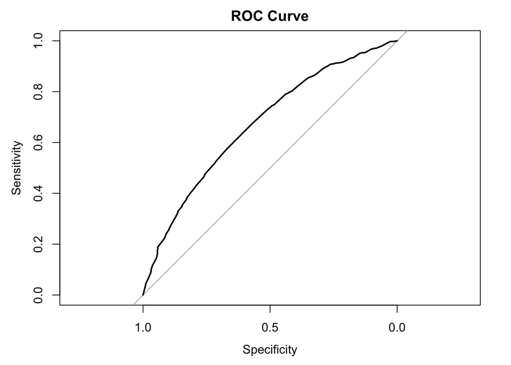

```r
# Predict probabilities
probabilities <- predict(random.forrest, data, type = "prob")

# Calculate ROC curve
roc_curve <- roc(response = data$target, predictor = probabilities[, "Donor"])
# Plot ROC curve
plot(roc_curve, main = "ROC Curve")
```

```r
auc(roc_curve)
```

```
## Area under the curve: 0.6718
```

```r
# Predict probabilities on the validation set
predictions <- predict(random.forrest, data, type = "prob")

# Extract the probabilities of the positive class (assuming 'Yes' is the positive class label)
probabilities <- predictions$Donor

# Define cost of sending a mail and average donation amount
cost_per_mail <- 0.68  # Cost of each mailing
average_donation <- 13.00  # Average donation received from a positive response

# Initialize a vector to store net profits for each threshold
thresholds <- seq(0.1, 0.9, by = 0.1)
net_profits <- numeric(length(thresholds))

# Calculate net profit for each threshold
for (i in seq_along(thresholds)) {
  cut_off <- thresholds[i]

  # Predict labels based on cut-off
  predicted_labels <- ifelse(probabilities > cut_off, 1, 0)

  # Calculate True Positives and False Positives
  true_positives <- sum(predicted_labels == 1 & data$target == "Donor")
  false_positives <- sum(predicted_labels == 1 & data$target == "No Donor")

  # Calculate cost and revenue
  cost <- false_positives * cost_per_mail
  revenue <- true_positives * average_donation

  # Calculate net profit
  net_profits[i] <- revenue - cost
}

# Identify the optimal threshold
optimal_index <- which.max(net_profits)
optimal_threshold <- thresholds[optimal_index]
optimal_net_profit <- net_profits[optimal_index]

cat("Optimal Cut-off:", optimal_threshold, "\n",
    "Maximum Net Profit:", optimal_net_profit, "\n")
```

```
## Optimal Cut-off: 0.1
##  Maximum Net Profit: 18356
```

## KNN

### Training

```r
library(caret)
set.seed(12345)  # for reproducibility

customSummary <- function(data, lev = NULL, model = NULL) {
  # Calculate confusion matrix
  conf <- confusionMatrix(data$pred, data$obs, positive = lev[2])

  # Extract metrics
  out <- c(accuracy = conf$overall['Accuracy'],
           precision = conf$byClass['Precision'],
           recall = conf$byClass['Recall'],
           F1 = conf$byClass['F1'])
  names(out) <- c("Accuracy", "Precision", "Recall", "F1")
  out
}

# Define the training control
train_control <- trainControl(
  method = "cv",             # Use cross-validation
  number = 10,               # Number of folds in the cross-validation
  savePredictions = "final", # Save predictions for each fold
  classProbs = TRUE,         # Save class probabilities for ROC analysis
  summaryFunction = customSummary  # Summary function for binary classification
)

# Define the tuning grid for KNN
tuning_grid <- expand.grid(k = seq(3, 21, by = 2))  # Test odd values of k from 3 to 21

knn_model <- train(target ~ months_since_donate + last_gift,
                   data = data,
                   method = "knn",
                   trControl = train_control,
                   tuneGrid = tuning_grid,
                   metric = "ROC",
                   preProcess = c("center", "scale"))  # Pre-processing step to scale and center data
```

### Results

```r
results <- knn_model$results
print(paste("Accuracy:", mean(results[, "Accuracy"])))
```

```
## [1] "Accuracy: 0.536911542350471"
```

```r
print(paste("Precision:",mean(results[, "Precision"])))
```

```
## [1] "Precision: 0.537554498603668"
```

```r
print(paste("Recall:",mean(results[, "Recall"])))
```

```
## [1] "Recall: 0.54051523178808"
```

```r
print(paste("F1:",mean(results[, "F1"])))
```

```
## [1] "F1: 0.53836474862091"
```

### Confusion Matrix

```r
# Best model's predictions
best_predictions <- knn_model$pred[knn_model$pred$k == knn_model$bestTune$k,]

# Confusion matrix
confusionMatrix(best_predictions$pred, best_predictions$obs)
```

```
## Confusion Matrix and Statistics
##
##           Reference
## Prediction Donor No.Donor
##   Donor      819      688
##   No.Donor   680      813
##
##                Accuracy : 0.544
##                  95% CI : (0.526, 0.5619)
##     No Information Rate : 0.5003
##     P-Value [Acc > NIR] : 9.296e-07
##
##                   Kappa : 0.088
##
##  Mcnemar's Test P-Value : 0.8499
##
##             Sensitivity : 0.5464
##             Specificity : 0.5416
##          Pos Pred Value : 0.5435
##          Neg Pred Value : 0.5445
##              Prevalence : 0.4997
##          Detection Rate : 0.2730
##    Detection Prevalence : 0.5023
##       Balanced Accuracy : 0.5440
##
##        'Positive' Class : Donor
##
```

### ROC Curve

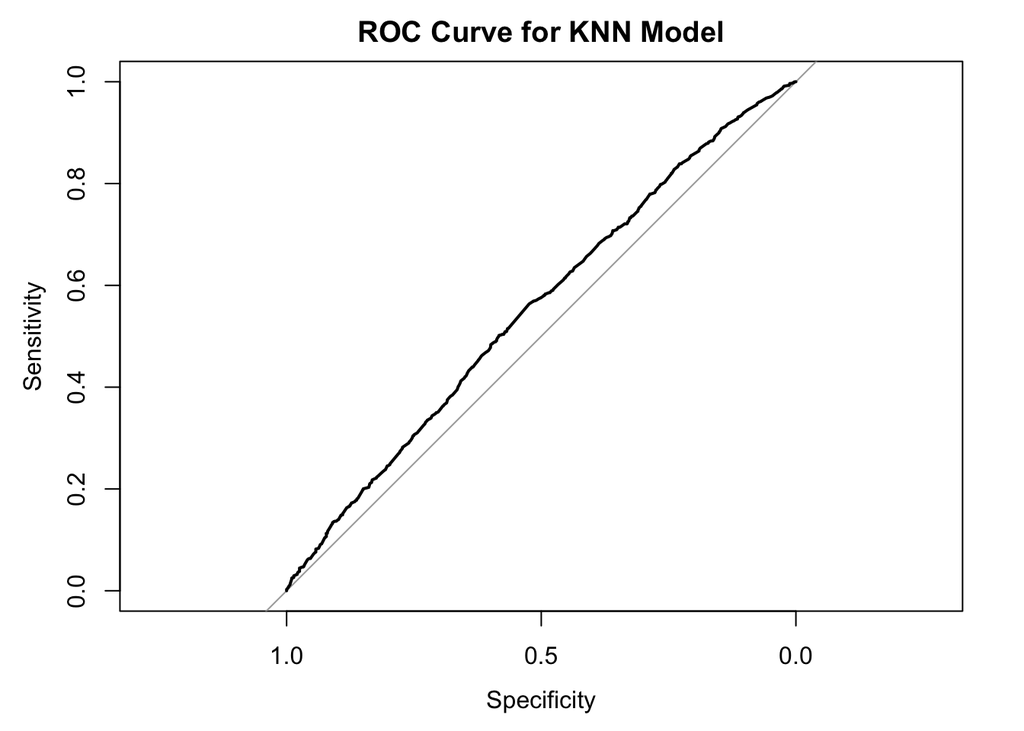

```r
library(pROC)

# ROC curve
roc_curve <- roc(best_predictions$obs, best_predictions$Donor)  # Ensure 'Donor' matches your positive class label
# Plot ROC
plot(roc_curve, main = "ROC Curve for KNN Model")
```

```r
# Print AUC
print(paste("AUC:", auc(roc_curve)))
```

```
## [1] "AUC: 0.553526468233986"
```

```r
# Predict probabilities on the validation set
predictions <- predict(knn_model, data, type = "prob")

# Extract the probabilities of the positive class (assuming 'Yes' is the positive class label)
probabilities <- predictions$Donor

# Define cost of sending a mail and average donation amount
cost_per_mail <- 0.68  # Cost of each mailing
average_donation <- 13.00  # Average donation received from a positive response

# Initialize a vector to store net profits for each threshold
thresholds <- seq(0.1, 0.9, by = 0.1)
net_profits <- numeric(length(thresholds))

# Calculate net profit for each threshold
for (i in seq_along(thresholds)) {
  cut_off <- thresholds[i]

  # Predict labels based on cut-off
  predicted_labels <- ifelse(probabilities > cut_off, 1, 0)

  # Calculate True Positives and False Positives
  true_positives <- sum(predicted_labels == 1 & data$target == "Donor")
  false_positives <- sum(predicted_labels == 1 & data$target == "No Donor")

  # Calculate cost and revenue
  cost <- false_positives * cost_per_mail
  revenue <- true_positives * average_donation

  # Calculate net profit
  net_profits[i] <- revenue - cost
}

# Identify the optimal threshold
optimal_index <- which.max(net_profits)
optimal_threshold <- thresholds[optimal_index]
optimal_net_profit <- net_profits[optimal_index]

cat("Optimal Cut-off:", optimal_threshold, "\n",
    "Maximum Net Profit:", optimal_net_profit, "\n")
```

```
## Optimal Cut-off: 0.1
##  Maximum Net Profit: 19487
```

## Getting Best Model Predictions

```r
# Load future dataset
future_data <- read.csv("future_fundraising.csv")

set.seed(12345)
# Initialize zipconvert1 with "No"
future_data$zipconvert1 <- "No"

# Set zipconvert1 to "Yes" where all other zipconverts are "No"
future_data$zipconvert1[with(future_data, zipconvert2 == "No" & zipconvert3 == "No" & zipconvert4 == "No" & zipconvert5 == "No")] <- "Yes"

future_data$zip_group[future_data$zipconvert1 == "Yes"] <- '1'
future_data$zip_group[future_data$zipconvert2 == "Yes"] <- '2'
future_data$zip_group[future_data$zipconvert3 == "Yes"] <- '3'
future_data$zip_group[future_data$zipconvert4 == "Yes"] <- '4'
future_data$zip_group[future_data$zipconvert5 == "Yes"] <- '5'

# Ensure it's a factor
future_data$zip_group <- as.factor(future_data$zip_group)

# Optionally remove the old zipconvert columns
future_data$zipconvert1 <- NULL
future_data$zipconvert2 <- NULL
future_data$zipconvert3 <- NULL
future_data$zipconvert4 <- NULL
future_data$zipconvert5 <- NULL

# Assuming 'target' and other categorical columns are set in the 'future_data'
future_data$homeowner <- as.factor(future_data$homeowner)
future_data$income <- as.factor(future_data$income)
future_data$female <- as.factor(future_data$female)
future_data$wealth <- as.factor(future_data$wealth)

str(future_data)
```

```
## 'data.frame':    120 obs. of  17 variables:
##  $ homeowner          : Factor w/ 2 levels "No","Yes": 2 2 2 2 2 2 2 2 1 1 ...
##  $ num_child          : int  1 1 1 1 1 1 1 1 1 1 ...
##  $ income             : Factor w/ 7 levels "1","2","3","4",..: 5 1 4 4 2 4 2 3 4 2 ...
##  $ female             : Factor w/ 2 levels "No","Yes": 2 1 2 1 2 2 2 1 1 1 ...
##  $ wealth             : Factor w/ 10 levels "0","1","2","3",..: 10 8 2 9 8 9 2 9 4 6 ...
##  $ home_value         : int  1399 1355 835 1019 992 834 639 457 349 698 ...
##  $ med_fam_inc        : int  637 411 310 389 524 371 209 253 302 335 ...
##  $ avg_fam_inc        : int  703 497 364 473 563 408 259 285 324 348 ...
##  $ pct_lt15k          : int  1 9 22 15 6 10 36 25 19 14 ...
##  $ num_prom           : int  74 77 70 21 63 35 72 68 55 59 ...
##  $ lifetime_gifts     : num  102 249 126 26 100 92 146 98 66 276 ...
##  $ largest_gift       : num  6 15 6 16 20 37 12 5 7 15 ...
##  $ last_gift          : num  5 7 6 16 3 37 11 3 5 13 ...
##  $ months_since_donate: int  29 35 34 37 21 37 36 32 30 33 ...
##  $ time_lag           : int  3 3 8 5 6 5 5 9 9 10 ...
##  $ avg_gift           : num  4.86 9.58 4.34 13 7.69 ...
##  $ zip_group          : Factor w/ 4 levels "2","3","4","5": 2 1 4 3 2 1 2 1 2 2 ...
```

```r
# Predict using the best model
predictions <- predict(knn_model, newdata=future_data)

levels(predictions) <- c("Donor", "No Donor")  # Adjust as necessary to match exact output requirements

#write.table(predictions, file = "Final_randomForest_predictions.csv", col.names = c("value"), row.names = FALSE)
```